# Exercise 5

Alexandra Anderson

2023-10-04

## Going Down Under

The Northern quoll is a medium sized marsupial that lives in rocky landscapes an Eucalyptus forests in Northern Australia. They are known as the “Northern native cat” and directly compete for many of the same food resources as introduced invasive feral cats. These animals and their interactions with each other are being intensively studied given the destructive nature of feral cats on native Australian wildlife.

The goal of the data I used is to look at the abundance of Northern Quolls, feral cats and their prey and the relationship of these with a variety of den types.

[Dryad Dataset](https://datadryad.org/stash/dataset/doi:10.5061/dryad.0gb5mkkxt)

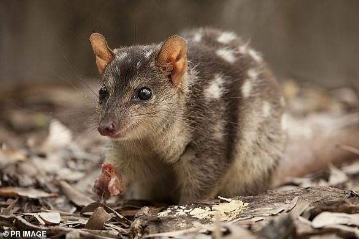

## Looking at Invasive and Endemic Predator Interactions

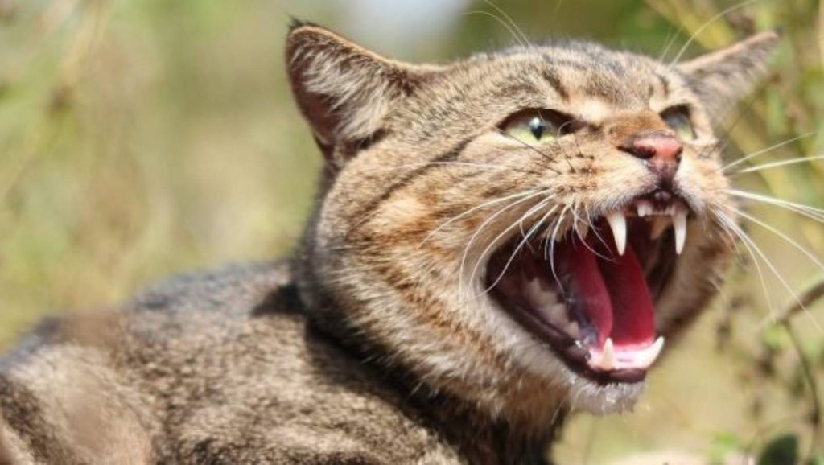

This first set of analysis is focusing on the relationship between the number of quolls and the number of feral cats within all of their study sites. As you can see from this graph, the number of quolls in the area is smaller when there are more feral cats.

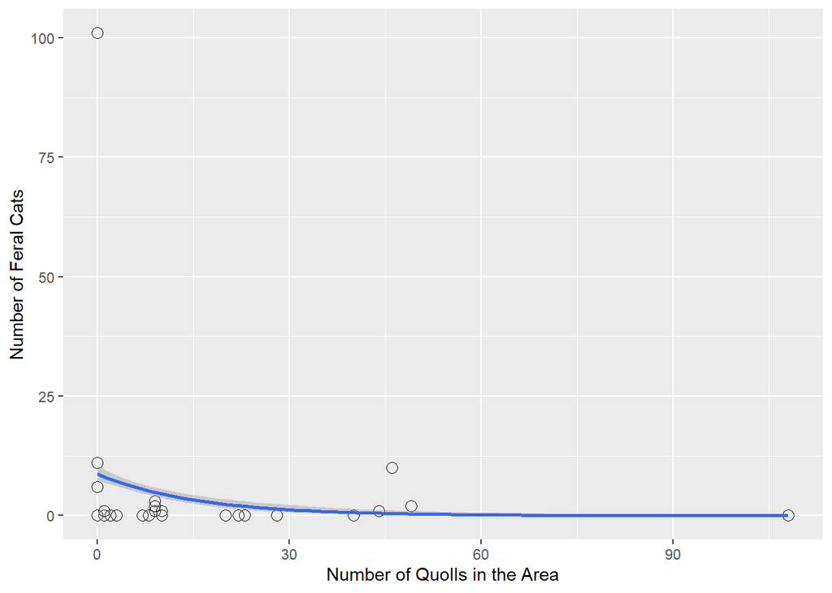

## Running the Models

```r
model_cat_poisson <- glm(northern.quoll ~ feral.cat, family = poisson, data=quolls)
summary(model_cat_poisson)
```

```
##
## Call:
## glm(formula = northern.quoll ~ feral.cat, family = poisson, data = quolls)
##
## Coefficients:
##             Estimate Std. Error z value Pr(>|z|)
## (Intercept)  2.85553    0.04959   57.58  < 2e-16 ***
## feral.cat   -0.03828    0.01153   -3.32 0.000899 ***
## ---
## Signif. codes:  0 '***' 0.001 '**' 0.01 '*' 0.05 '.' 0.1 ' ' 1
##
## (Dispersion parameter for poisson family taken to be 1)
##
##     Null deviance: 751.16  on 28  degrees of freedom
## Residual deviance: 716.14  on 27  degrees of freedom
## AIC: 811.14
##
## Number of Fisher Scoring iterations: 8
```

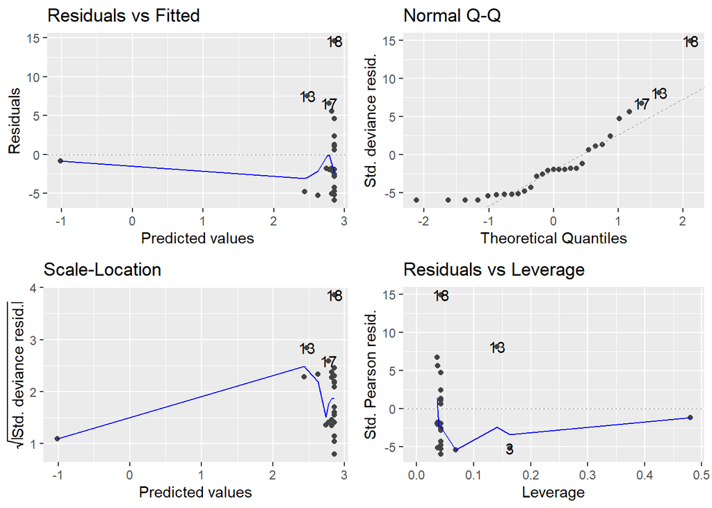

```r
autoplot(model_cat_poisson)
```

Running a quasi-poisson model shows an about equal distribution of points, and the p-value is now insignificant, so it is not helpful in this case.

```r
model_cat_quasi <- glm(northern.quoll ~ feral.cat, family = quasipoisson, data = quolls)
summary(model_cat_quasi)
```

```
##
## Call:
## glm(formula = northern.quoll ~ feral.cat, family = quasipoisson,
##     data = quolls)
##
## Coefficients:
##             Estimate Std. Error t value Pr(>|t|)
## (Intercept)  2.85553    0.28849   9.898 1.77e-10 ***
## feral.cat   -0.03828    0.06707  -0.571    0.573
## ---
## Signif. codes:  0 '***' 0.001 '**' 0.01 '*' 0.05 '.' 0.1 ' ' 1
##
## (Dispersion parameter for quasipoisson family taken to be 33.83961)
##
##     Null deviance: 751.16  on 28  degrees of freedom
## Residual deviance: 716.14  on 27  degrees of freedom
## AIC: NA
##
## Number of Fisher Scoring iterations: 8
```

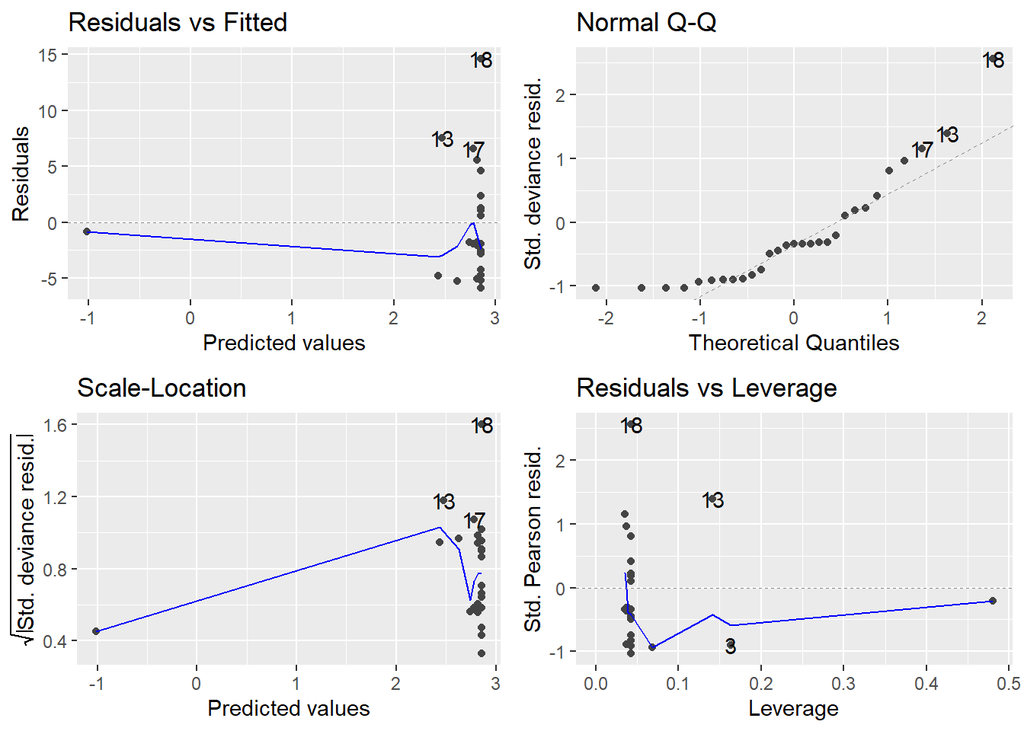

```r
autoplot(model_cat_quasi)
```

## Looking at Native Predator/Prey Abundance

Quolls are carnivorous and insectivorous. Their diet consists of insects, small mammals, small lizards and occasionally small birds. Feral cats are direct competitors because of their similar diet. For this section, I focused on quolls and the abundance of prey items available to them.

[figure not shown]

*A tasty snack bigger than your head.*

[video not shown]

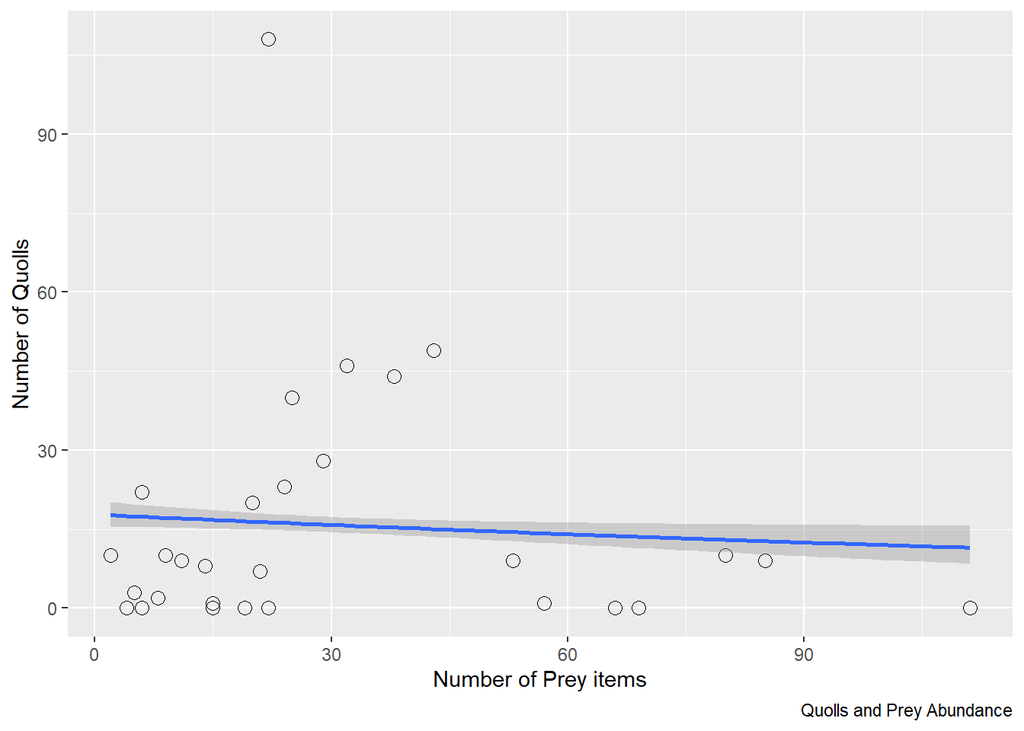

Looking at this visualization, there is not a clear relationship between the number of prey items available and the presence of quolls at the different sites.

```r
model_diversity_poisson <- glm(total ~ northern.quoll, family = poisson, data=quolls)
summary(model_diversity_poisson)
```

```
##
## Call:
## glm(formula = total ~ northern.quoll, family = poisson, data = quolls)
##
## Coefficients:
##                 Estimate Std. Error z value Pr(>|z|)
## (Intercept)     3.490754   0.040034  87.194   <2e-16 ***
## northern.quoll -0.002880   0.001559  -1.848   0.0646 .
## ---
## Signif. codes:  0 '***' 0.001 '**' 0.01 '*' 0.05 '.' 0.1 ' ' 1
##
## (Dispersion parameter for poisson family taken to be 1)
##
##     Null deviance: 637.14  on 28  degrees of freedom
## Residual deviance: 633.54  on 27  degrees of freedom
## AIC: 779
##
## Number of Fisher Scoring iterations: 5
```

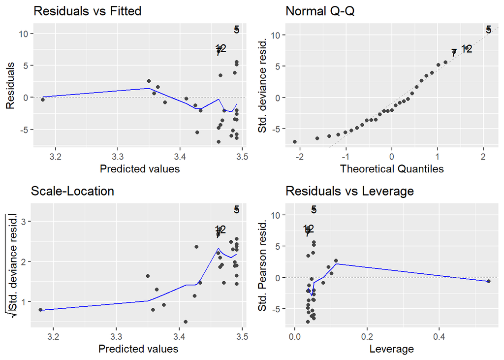

```r
autoplot(model_diversity_poisson)
```

```r
model_diversity_quasi <- glm(total ~ northern.quoll, family = quasipoisson, data = quolls)
summary(model_diversity_quasi)
```

```
##
## Call:
## glm(formula = total ~ northern.quoll, family = quasipoisson,
##     data = quolls)
##
## Coefficients:
##                 Estimate Std. Error t value Pr(>|t|)
## (Intercept)     3.490754   0.200764  17.387 3.43e-16 ***
## northern.quoll -0.002880   0.007816  -0.369    0.715
## ---
## Signif. codes:  0 '***' 0.001 '**' 0.01 '*' 0.05 '.' 0.1 ' ' 1
##
## (Dispersion parameter for quasipoisson family taken to be 25.14809)
##
##     Null deviance: 637.14  on 28  degrees of freedom
## Residual deviance: 633.54  on 27  degrees of freedom
## AIC: NA
##
## Number of Fisher Scoring iterations: 5
```

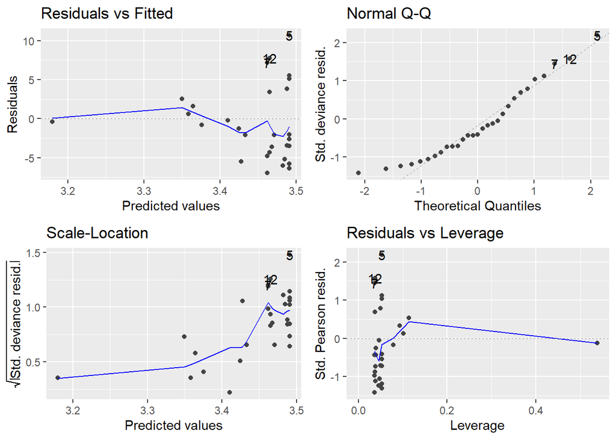

```r
autoplot(model_diversity_quasi)
```

## Looking at Native Predator in Treatment Areas

This study looked at different treatment sites for Northern Quoll dens. There is an artificially created quoll den treatment, a natural unoccupied treatment and a natural occupied treatment. I chose to investigate prey availability and quoll detection in relation to the treatment area types.

[figure not shown]

*A Natural Occupied Den*

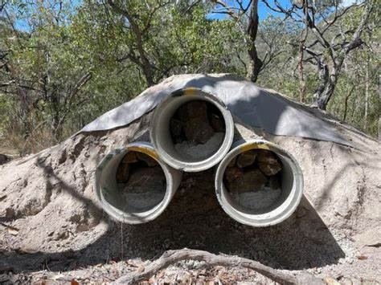

*Artificial Dens*

```r
Treatment.pois <- glm(total~northern.quoll*Treatment, family= poisson(link=log), data= quolls)
```

```r
summary(Treatment.pois)
```

```
##
## Call:
## glm(formula = total ~ northern.quoll * Treatment, family = poisson(link = log),
##     data = quolls)
##
## Coefficients:
##                                     Estimate Std. Error z value Pr(>|z|)
## (Intercept)                         3.494790   0.066742  52.363  < 2e-16 ***
## northern.quoll                     -0.002271   0.004896  -0.464  0.64277
## TreatmentOccupied                   0.254862   0.096482   2.642  0.00825 **
## TreatmentUnoccupied                -0.097337   0.107969  -0.902  0.36731
## northern.quoll:TreatmentOccupied   -0.003130   0.005236  -0.598  0.54993
## northern.quoll:TreatmentUnoccupied -0.016407   0.008418  -1.949  0.05129 .
## ---
## Signif. codes:  0 '***' 0.001 '**' 0.01 '*' 0.05 '.' 0.1 ' ' 1
##
## (Dispersion parameter for poisson family taken to be 1)
##
##     Null deviance: 637.14  on 28  degrees of freedom
## Residual deviance: 598.00  on 23  degrees of freedom
## AIC: 751.45
##
## Number of Fisher Scoring iterations: 5
```

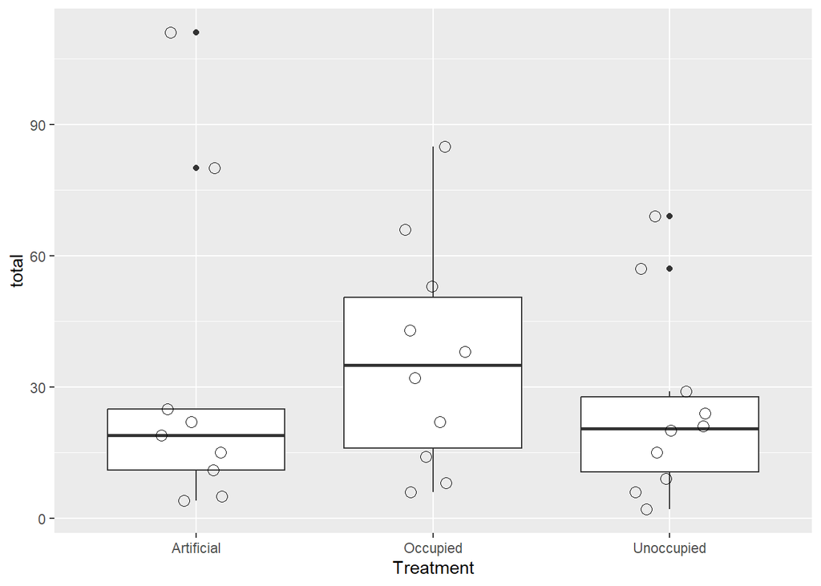

```r
ggplot(quolls, aes(Treatment, total)) +
  geom_boxplot() +
  geom_jitter(shape=1, size=3, height = 0, width = .15)
```

I was going to do a model coefficient plot, but I was not happy where it was visually and for me it was just as difficult to read as the standard summary.

```r
qpois1 <- glm(total~northern.quoll*Treatment, quasipoisson, data= quolls)
summary(qpois1)
```

```
##
## Call:
## glm(formula = total ~ northern.quoll * Treatment, family = quasipoisson,
##     data = quolls)
##
## Coefficients:
##                                     Estimate Std. Error t value Pr(>|t|)
## (Intercept)                         3.494790   0.347734  10.050 6.95e-10 ***
## northern.quoll                     -0.002271   0.025509  -0.089    0.930
## TreatmentOccupied                   0.254862   0.502684   0.507    0.617
## TreatmentUnoccupied                -0.097337   0.562532  -0.173    0.864
## northern.quoll:TreatmentOccupied   -0.003130   0.027279  -0.115    0.910
## northern.quoll:TreatmentUnoccupied -0.016407   0.043858  -0.374    0.712
## ---
## Signif. codes:  0 '***' 0.001 '**' 0.01 '*' 0.05 '.' 0.1 ' ' 1
##
## (Dispersion parameter for quasipoisson family taken to be 27.14543)
##
##     Null deviance: 637.14  on 28  degrees of freedom
## Residual deviance: 598.00  on 23  degrees of freedom
## AIC: NA
##
## Number of Fisher Scoring iterations: 5
```

```r
coef(qpois1)
```

```
##                        (Intercept)                     northern.quoll
##                        3.494790326                       -0.002270923
##                  TreatmentOccupied                TreatmentUnoccupied
##                        0.254862098                       -0.097336817
##   northern.quoll:TreatmentOccupied northern.quoll:TreatmentUnoccupied
##                       -0.003130300                       -0.016406769
```

```r
confint(qpois1)
```

```
##                                          2.5 %     97.5 %
## (Intercept)                         2.73417504 4.11252518
## northern.quoll                     -0.06659282 0.03980221
## TreatmentOccupied                  -0.74077962 1.25652835
## TreatmentUnoccupied                -1.26038681 0.98755279
## northern.quoll:TreatmentOccupied   -0.05043153 0.06322562
## northern.quoll:TreatmentUnoccupied -0.10637940 0.07263221
```